# Title

#### Second term

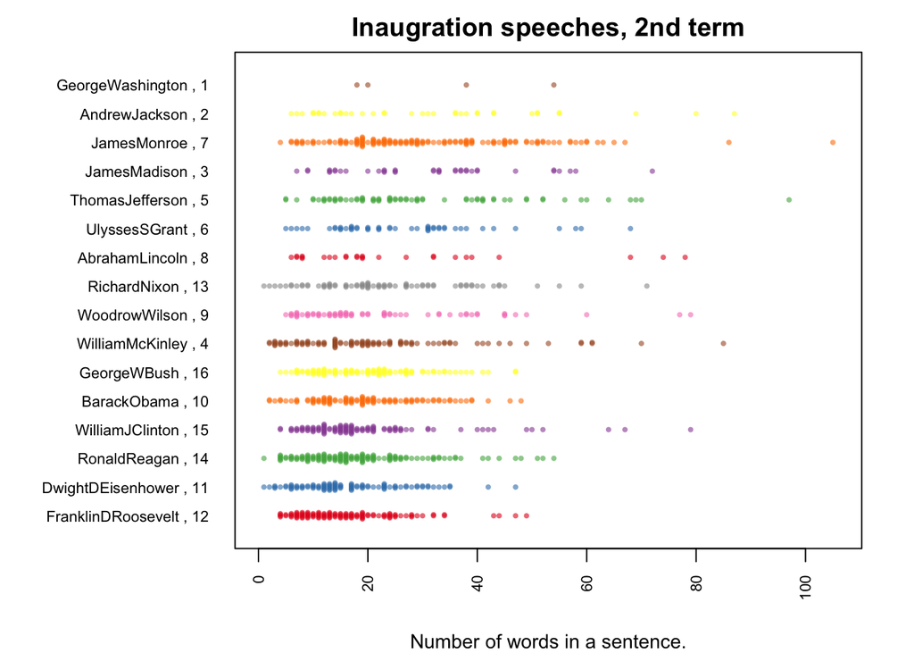

We can compare the presidents’ sentence length in each term. From the plot above, the number behind the president’s name represents his ranking in the first plot. The ranking looks increasing instead of random suggust that every president has his own pace of the inauguration speech.

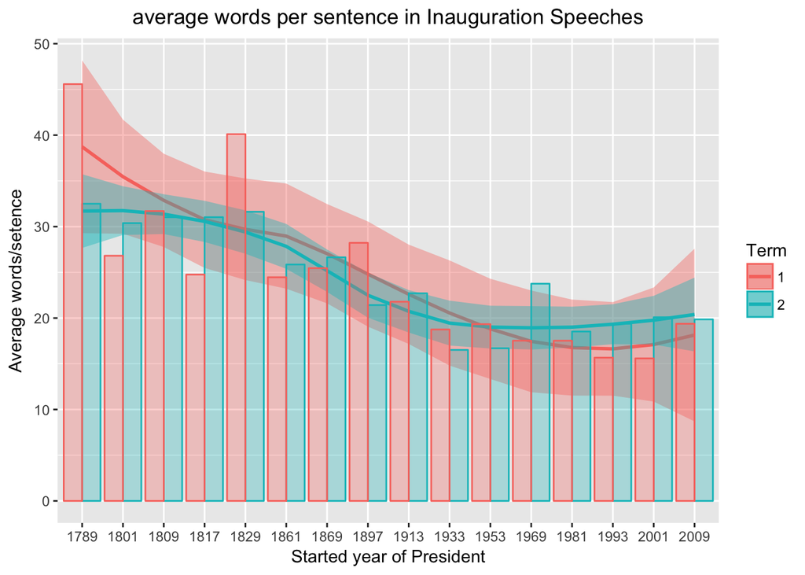

```r
par(mfrow=c(1,2))
Presidents2terms <- data.frame(names(tapply(sentence.list.inaug$word.count, sentence.list.inaug$File, sum)))
names(Presidents2terms) <- c("Name")

Presidents2terms $WordCountSum1st <- as.vector(tapply(sentence.list.inaug$word.count, sentence.list.inaug$File, sum))
Presidents2terms $WordCountMean1st <- as.vector(tapply(sentence.list.inaug$word.count, sentence.list.inaug$File, mean))

Presidents2terms $WordCountSum2nd <- as.vector(tapply(sentence.list.inaug2$word.count, sentence.list.inaug2$File, sum))
Presidents2terms $WordCountMean2nd <- as.vector(tapply(sentence.list.inaug2$word.count, sentence.list.inaug2$File, mean))
Presidents2terms $Party <- factor(c("Republican", "Democratic", "Democratic", "Republican", "Democratic", NA, "Republican", "Democratic-Republican", "Democratic-Republican", "Republican", "Republican", "Democratic-Republican", "Republican", "Democratic", "Republican", "Democratic"))

Presidents2terms $ WordSum <- Presidents2terms $WordCountSum1st
Presidents2terms $ WordMean <- Presidents2terms $WordCountMean1st

Presidents2terms $StartYear <- c(1861, 1829, 2009, 1953, 1933, 1789, 2001, 1809, 1817, 1969, 1981, 1801, 1869, 1993, 1897, 1913)

Presidents2terms <- rbind(Presidents2terms, Presidents2terms)
Presidents2terms $ Term <- factor(c(rep(1, 16), rep(2, 16)))

Presidents2terms $ WordSum[Presidents2terms $ Term == 2] <- Presidents2terms $WordCountSum2nd[Presidents2terms $ Term == 2]
Presidents2terms $ WordMean[Presidents2terms $ Term == 2] <- Presidents2terms $WordCountMean2nd[Presidents2terms $ Term == 2]

ggplot(data = Presidents2terms, aes(as.character(StartYear), WordMean, group = Term, fill = Term, color = Term)) + geom_smooth(method = "loess") + geom_col(position = "dodge", alpha = 0.3) + xlab("Started year of President") + ylab("Average words/setence") + ggtitle("average words per sentence in Inauguration Speeches") + theme(plot.title = element_text(hjust = 0.5))
```

If we check the data in a time order, we would find that the average sentence length is decreasing, which infer the writing habit is changed over decades. The fact that two term lines are close shows that the president did not change their writing habit in 4 years.

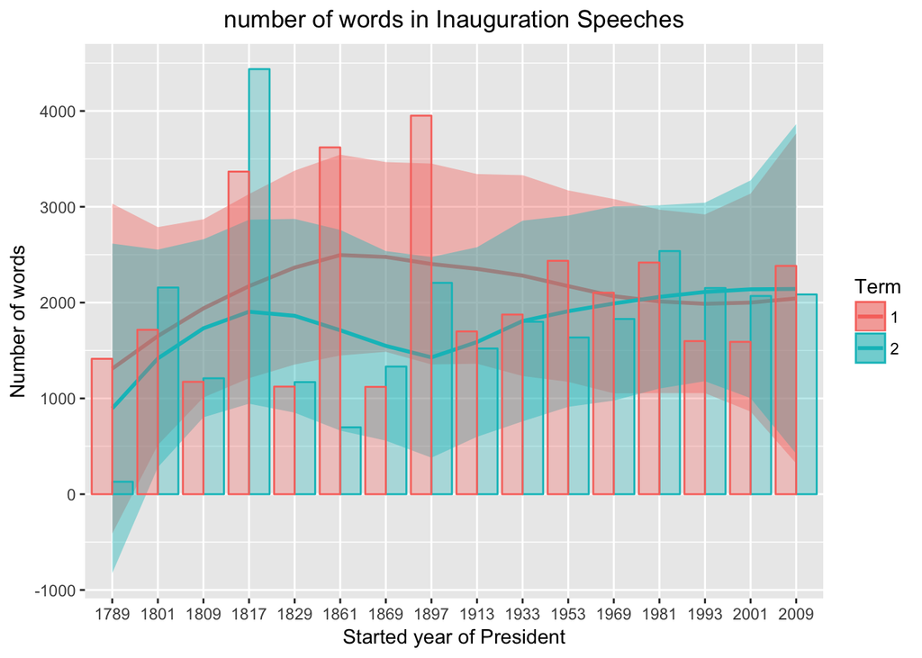

```r
ggplot(data = Presidents2terms, aes(as.character(StartYear), WordSum, group = Term, fill = Term, color = Term)) + geom_smooth(method = "loess") + geom_col(position = "dodge", alpha = 0.3) + xlab("Started year of President") + ylab("Number of words") + ggtitle("number of words in Inauguration Speeches") + theme(plot.title = element_text(hjust = 0.5))
```

This plot show the whole passage length in inauguration speech. From the plot the 2nd term line is below the 1st line before 1980. One possibility is that the repeated official words could be omitted. In the past 30 year two lines are very close, which means the two term inauguration speech are of equal importance.

## II.2 word frequency

Another vital analysis is the word frequency. Why is it important? By finding which words a president was likely to say, we could be able to analyze the president’s character, political position, personal intension and even future action.

For example, I wrote a function to check whther a president says a word in his inauguration speeches. Here are some examples:

```r
Search_Words <- function(Word, Name, Terms)
{
  Str <- as.matrix(sentence.list%>%filter(File == Name, Term == Terms)
                   %>% select(sentences))
  return(Str[grep(Word, Str)])
}
## Search "Word" From President's "Name"

Search_Words("gay", "BarackObama", 2)
```

```
## [1] "Our journey is not complete until our gay brothers and sisters are treated like anyone else under the law—for if we are truly created equal, then surely the love we commit to one another must be equal as well."
```

```r
length(Search_Words("great", "DonaldJTrump", 1))
```

```
## [1] 6
```

```r
length(Search_Words("war", "AbrahamLincoln", 2))
```

```
## [1] 9
```

```r
length(Search_Words("tyranny", "GeorgeWBush", 2))
```

```
## [1] 5
```

```r
length(Search_Words("freedom", "GeorgeWBush", 2))
```

```
## [1] 25
```